# M2DS - SMA Prof. Khalid OQAIDI

## Contrôle Continu : Analyse d'un Réseau Scientifique avec NetworkX

### Guide du TP : Analyse d'un Réseau Scientifique avec NetworkX

# Realisé Par: ABDENNACER Elbasri

## M2DS

#### Ce travail est executé sur google colab est accessible via le lien: https://colab.research.google.com/drive/1ahGY5QHoT27d3i2Zg_0tuvLdl-ifE_ag?usp=sharing

### Étape 1 : Installation des Bibliothèques:

- NetworkX
- Pandas
- Matplotlib

```python
# Étape 2 : Importation des Bibliothèques
import networkx as nx
import pandas as pd
import matplotlib.pyplot as plt
```

### Étape 3 : Chargement des Données

Source (http://snap.stanford.edu/data/ca-GrQc.html)

```python
data = pd.read_csv('CA-GrQc.txt', sep='\t', comment='#', header=None)
data.columns = ['source', 'target']
```

```python
# Dataframe lines info:
data.head()
```

|  | source | target |
| --- | --- | --- |
| 0 | 3466 | 937 |
| 1 | 3466 | 5233 |
| 2 | 3466 | 8579 |
| 3 | 3466 | 10310 |
| 4 | 3466 | 15931 |

### Étape 4 : Création du Graphe

Construction d'un graphe non orienté à partir des données de collaboration

```python
# soit: G = nx.from_pandas_edgelist(data, 'source', 'target')
# ou:
G = nx.Graph()
G.add_edges_from(data.values)

# Affichage du nombre total de nœuds et d'arêtes
print(f"Nombre de nœuds : {G.number_of_nodes()}")
print(f"Nombre d'arêtes : {G.number_of_edges()}")
```

```
Nombre de nœuds : 5242
Nombre d'arêtes : 14496
```

### Étape 5 : Analyse Préliminaire

Calcul et affichage du degré moyen des nœuds

```python
degree_mean = sum(dict(G.degree()).values()) / G.number_of_nodes()
print(f"Degré moyen des nœuds : {degree_mean}")
```

```
Degré moyen des nœuds : 5.530713468141931
```

```python
# Distribution des degrés
degree_sequence = [d for n, d in graph.degree()]
degree_count = pd.Series(degree_sequence).value_counts().sort_index()

print("\nDistribution des degrés :")
print(degree_count)
```

```
Distribution des degrés :
1     1196
2     1114
3      775
4      497
5      299
      ...
67       1
68       2
77       2
79       1
81       1
Name: count, Length: 65, dtype: int64
```

Le degré moyen des nœuds nous donne une idée de la connectivité générale du réseau. Un degré moyen élevé indiquerait que les auteurs collaborent largement, tandis qu'un degré faible indiquerait des collaborations limitées.

Calcul de la distribution des degrés et tracé d'un histogramme représentant la distribution des degrés

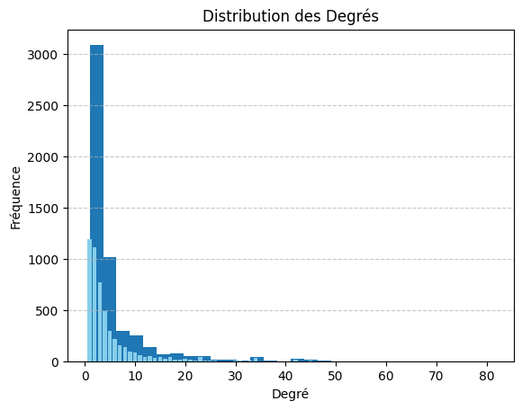

```python
degrees = [degree for node, degree in G.degree()]

plt.hist(degrees, bins=30)
plt.bar(degree_count.index, degree_count.values, color="skyblue")
plt.xlabel('Degré')
plt.ylabel('Fréquence')
plt.title('Distribution des Degrés')
plt.grid(axis="y", linestyle="--", alpha=0.7)
plt.show()
```

L'histogramme de la distribution des degrés nous montre comment les collaborations sont réparties. Si la distribution présente une longue traîne, cela signifie que peu d'auteurs collaborent beaucoup, tandis que la plupart ont peu de collaborations. Cela est typique des réseaux sociaux où certaines personnes sont très connectées.

### Étape 6 : Visualisation

Sélection d'un sous-graphe basé sur les nœuds ayant un degré élevé

```python
# Sélection des nœuds avec un degré élevé (par exemple, degré ≥ 20)
high_degree_nodes = [node for node, degree in G.degree() if degree >= 20]
subgraph = G.subgraph(high_degree_nodes)
```

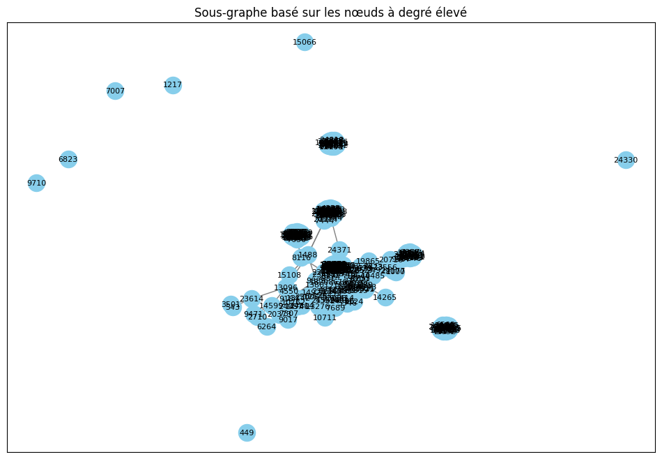

```python
# Visualisation du sous-graphe
plt.figure(figsize=(12, 8))
pos = nx.spring_layout(subgraph, seed=42)  # Disposition Spring Layout
nx.draw_networkx(
    subgraph,
    pos,
    with_labels=True,
    node_size=300,
    node_color="skyblue",
    edge_color="gray",
    font_size=8,
    font_color="black"
)
plt.title("Sous-graphe basé sur les nœuds à degré élevé")
plt.show()
```

En visualisant ce sous-graphe, nous remarquons que les nœuds avec un degré élevé sont souvent des centres névralgiques du réseau, représentant des auteurs ayant collaboré avec de nombreux autres auteurs. Ces nœuds peuvent être considérés comme des hubs influents dans le réseau scientifique.

### Étape 7 : Calcul des Mesures de Centralité

```python
# calcul de la centralité de degré
degree_centrality = nx.degree_centrality(G)
# on peut afficher la liste de la centralité de degré par :
# print(degree_centrality)
top_degree = sorted(degree_centrality.items(), key=lambda x: x[1], reverse=True)[:5]

# Afficher les résultats
print("\nTop 5 des nœuds avec la plus grande centralité d'intermédiarité:")
for node, centrality in top_degree:
    print(f"Nœud {node}: Centralité d'Intermédiarité = {centrality}")
```

[output not shown]

Les nœuds ayant la plus grande centralité de degré sont ceux qui ont le plus grand nombre de connexions directes. Cela signifie qu'ils collaborent avec de nombreux autres auteurs, jouant un rôle crucial dans la diffusion de l'information.

```python
# Calcul de la centralité d'intermédiarité
betweenness_centrality = nx.betweenness_centrality(G)
top_betweenness = sorted(betweenness_centrality.items(), key=lambda x: x[1], reverse=True)[:5]

# Afficher les résultats
print("\nTop 5 des nœuds avec la plus grande centralité de proximité:")
for node, centrality in top_betweenness:
    print(f"Nœud {node}: Centralité de Proximité = {centrality}")
```

[output not shown]

Les nœuds ayant une forte centralité d'intermédiarité sont souvent des ponts dans le réseau, jouant un rôle clé dans la connexion de différentes parties du réseau. Ces nœuds sont essentiels pour la circulation de l'information.

```python
# Calcul de la centralité de proximité
proximity_centrality = nx.closeness_centrality(G)
top_proximity = sorted(proximity_centrality.items(), key=lambda x: x[1], reverse=True)[:5]
print("Top 5 nœuds par centralité de proximité :", top_proximity)
```

```
Top 5 nœuds par centralité de proximité : [(13801, 0.19428463503141283), (14485, 0.18953808583111678), (9572, 0.18903821471838708), (17655, 0.18896237842386998), (2654, 0.18712852106232164)]
```

Les nœuds ayant une grande centralité de proximité peuvent atteindre rapidement d'autres nœuds du réseau. Ces auteurs peuvent ainsi collaborer plus efficacement, car ils sont proches des autres au sein du réseau.

### Étape 8 : Détection des Communautés

```python
from networkx.algorithms.community import greedy_modularity_communities

# Application de l'algorithme de détection de communautés
communities = list(greedy_modularity_communities(G))
print(f"Nombre total de communautés détectées : {len(communities)}")
```

```
Nombre total de communautés détectées : 417
```

Les communautés détectées représentent des groupes d'auteurs ayant collaboré plus intensément entre eux qu'avec les autres membres du réseau. Cela est souvent révélateur de groupes de recherche ou de collaborations sur des sujets communs.

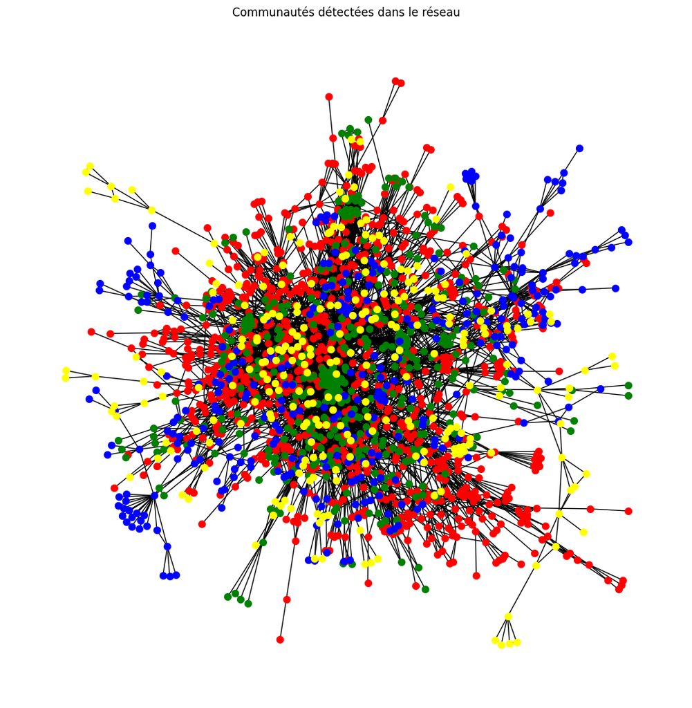

```python
# Coloration des nœuds d'un sous-graphe en fonction des communautés détectées
colors = ['red', 'green', 'blue', 'yellow']
plt.figure(figsize=(10, 10))
for i, community in enumerate(communities[:4]):  # Visualisation des premières communautés uniquement
    nx.draw(G.subgraph(community), node_color=colors[i], with_labels=False, node_size=50)
plt.title('Communautés détectées dans le réseau')
plt.show()
```

### Étape 9 : Calcul du Coefficient de Clustering

```python
# Calcul du coefficient de clustering moyen du réseau
clustering_coefficient = nx.average_clustering(G)
print(f"Coefficient de clustering moyen : {clustering_coefficient}")
```

```
Coefficient de clustering moyen : 0.529635811052136
```

Un coefficient de clustering élevé indique que les voisins d'un nœud sont souvent eux-mêmes connectés. Cela suggère une forte cohésion locale, typique des réseaux où des groupes de nœuds forment des communautés bien définies.

### Étape 10 : Conclusion

Conclusion basée sur les observations des résultats :

- **Principales observations** : Les nœuds avec un degré élevé sont au centre du réseau.
- **Nœuds importants** : Les mesures de centralité montrent certains nœuds clés dans la connectivité globale.
- **Communautés** : Les communautés détectées révèlent des groupes de chercheurs ayant collaboré ensemble.
- **Implications** : Cela permet de mieux comprendre la structure collaborative entre les auteurs du domaine et de visualiser les dynamiques de collaboration.

```python
#!pip install nbconvert
```

```python
!jupyter nbconvert --to html /content/Analyse_Reseau_Scientifique_Detaillee.ipynb
```

```
[NbConvertApp] Converting notebook /content/Analyse_Reseau_Scientifique_Detaillee.ipynb to html
[NbConvertApp] WARNING | Alternative text is missing on 3 image(s).
[NbConvertApp] Writing 1020517 bytes to /content/Analyse_Reseau_Scientifique_Detaillee.html
```